# R Econ Visual Library

R Econ Visual Library contains graphs created in R to explore impact evaluation data sets and display results. The Rmarkdown scripts and data sets used to create the Library’s graphs are stored in the [R Econ Visual Library GitHub repository](https://github.com/worldbank/r-econ-visual-library).

## Summary Statistics

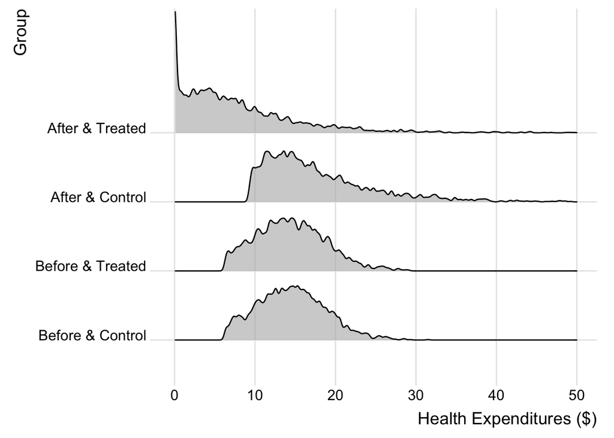

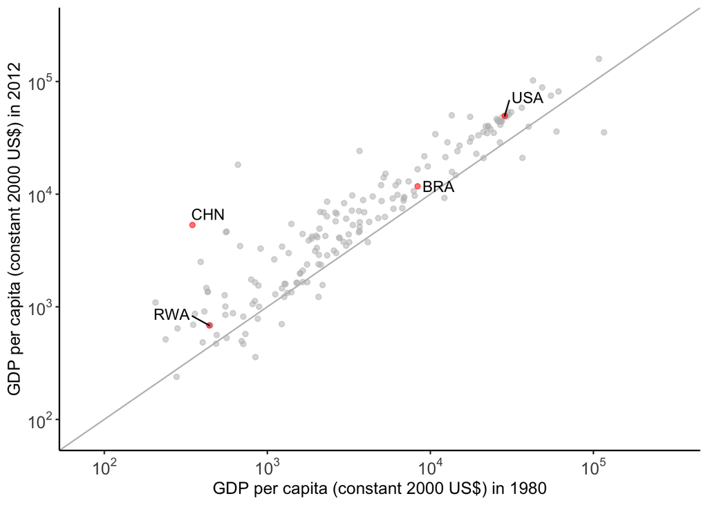

- Bar Plots
- Density Plots
- Scatter Plots

## Impact Evaluation

- Regression Coefficients
- Difference-in-Differences / Event Study
- Randomization Inference
- Regression Discontinuity Design

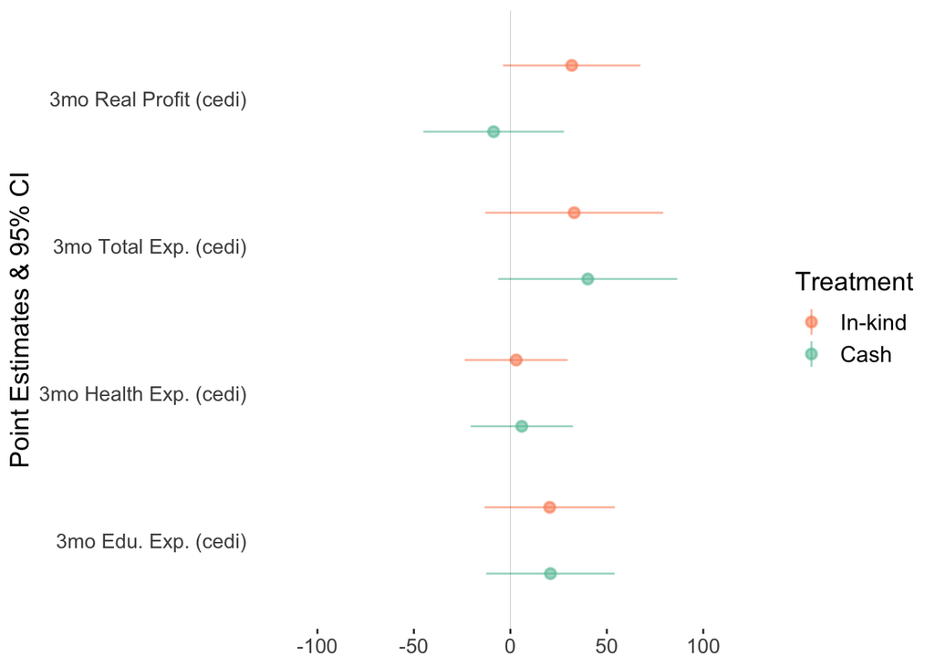

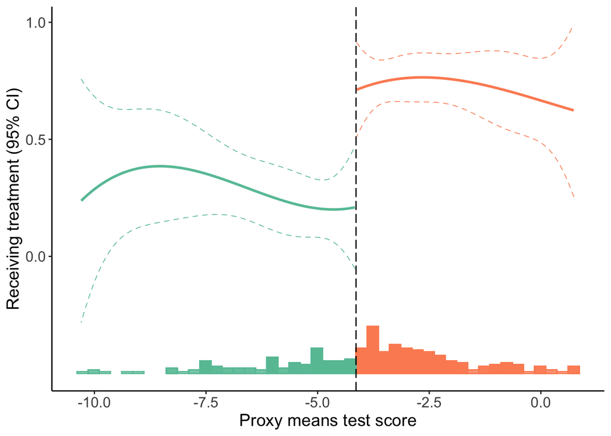

## Useful links

- [DIME Wiki](https://dimewiki.worldbank.org/wiki/Main_Page)
- [Data Visualization Cheatsheet](https://rstudio.com/resources/cheatsheets/))
- [Introduction to R for advanced Stata users](https://github.com/worldbank/dime-r-training)
- [The R Graph Gallery](https://www.r-graph-gallery.com/)
- [ggplot2: Elegant Graphics for Data Analysis](https://ggplot2-book.org/)
- [Data Visualization with R](https://rkabacoff.github.io/datavis/)
- [Coding Practices](https://dimewiki.worldbank.org/wiki/Stata_Coding_Practices)

About us

[DIME](https://www.worldbank.org/en/research/dime) is the impact evaluation unit of the World Bank Research Group. Part of DIME’s mission is to intensify the production of and access to public goods that improve the quantity and quality of global development research, while lowering the costs of doing IE for the entire research community. This Library is developed and maintained by the DIME Analytics team, a new initiative to provide data quality assurance to all DIME impact evaluations.